# InfoViz Project 1 on Maps

Air Quality Spatial Variations

Vijay Kumar and Muhammad Rashid

12/06/2022

The project 1 is focused on visualization of PM$_{2.5}$ concentrations and Air Quality index (AQI) on US map.

```r
library(readr)
library(tidyr)
library(dplyr)
library(ggplot2)
library(lubridate)
```

Data collection:

The data was collected from US EPA database at https://aqs.epa.gov/aqsweb/airdata/download_files.html.

```r
aqi <- read_csv("annual_aqi_by_county_2021.csv")
pmaqi<-read_csv("daily_88101_2021.csv")
```

Pre-Processing: Renaming variable is important in R coding, space in letters or large names create problem.

```r
pmaqi <-
  pmaqi %>%
  dplyr::select(`State Name`, `County Name`, `Site Num`, `Date Local`,
         `Arithmetic Mean`, AQI, Longitude, Latitude) %>%
  filter(`Arithmetic Mean` >= 0) %>%
  drop_na()
names(pmaqi) <- c("statename", "countyname", "sitenum", "date",
                     "pm25", "aqi",  "long", "lat")
```

Data Summary: Lets look if we find summary statistics of PM$_{2.5}$ based on states. The whole idea is coming from the fact that annual average PM$_{2.5}$ should be less than $12 \frac{ug}{m^3}$ according to EPA standards [1].

```r
a<-pmaqi%>%
  dplyr::group_by(statename)%>%# Summary by group using dplyr
  dplyr::summarize(
    n=n(),
    min = round(min(pm25),1),
    q1 = quantile(pm25, 0.25),
    median = round(median(pm25),1),
    mean = round(mean(pm25),1),
    q3 = quantile(pm25, 0.75),
    max = round(max(pm25),1),
    sd=round(sd(pm25,na.rm = TRUE),1))
knitr::kable(a, format = "markdown")
```

| statename | n | min | q1 | median | mean | q3 | max | sd |
| --- | --- | --- | --- | --- | --- | --- | --- | --- |
| Alabama | 3219 | 0.8 | 5.500 | 7.6 | 8.7 | 10.500 | 52.1 | 4.7 |
| Alaska | 2139 | 0.0 | 2.700 | 4.5 | 7.3 | 8.200 | 103.1 | 9.2 |
| Arizona | 6480 | 0.0 | 5.000 | 6.9 | 8.4 | 9.900 | 222.4 | 6.5 |
| Arkansas | 2206 | 0.8 | 5.825 | 8.2 | 9.2 | 11.400 | 35.3 | 4.7 |
| California | 42481 | 0.0 | 5.000 | 8.0 | 10.2 | 12.000 | 556.7 | 10.6 |
| Colorado | 6271 | 0.0 | 4.200 | 6.5 | 8.4 | 10.200 | 67.9 | 6.8 |
| Connecticut | 3681 | 0.2 | 4.500 | 6.6 | 7.7 | 9.300 | 52.6 | 5.1 |
| Country Of Mexico | 1052 | 1.4 | 10.600 | 15.1 | 19.6 | 23.500 | 107.1 | 14.2 |
| Delaware | 2252 | 1.2 | 5.100 | 7.0 | 8.0 | 9.600 | 52.8 | 4.5 |
| District Of Columbia | 1542 | 0.3 | 5.500 | 7.8 | 8.7 | 10.700 | 58.9 | 4.9 |
| Florida | 9112 | 0.3 | 5.600 | 7.0 | 7.6 | 8.900 | 42.8 | 3.2 |
| Georgia | 6400 | 0.9 | 6.300 | 8.5 | 9.7 | 11.625 | 60.7 | 5.1 |
| Hawaii | 4847 | 0.0 | 1.800 | 2.8 | 3.1 | 4.000 | 16.4 | 1.8 |
| Idaho | 1657 | 0.6 | 3.900 | 6.4 | 9.6 | 11.000 | 112.3 | 10.4 |
| Illinois | 8165 | 0.7 | 6.000 | 8.6 | 9.5 | 11.900 | 40.8 | 4.9 |
| Indiana | 10450 | 0.1 | 6.000 | 8.5 | 9.7 | 12.000 | 89.5 | 5.4 |
| Iowa | 4870 | 0.0 | 5.000 | 7.5 | 8.5 | 10.700 | 79.4 | 5.1 |
| Kansas | 2388 | 0.6 | 6.300 | 8.8 | 10.1 | 12.200 | 55.8 | 6.1 |
| Kentucky | 6971 | 0.3 | 6.100 | 8.1 | 9.5 | 11.300 | 73.9 | 5.1 |
| Louisiana | 2618 | 1.2 | 5.500 | 7.3 | 7.9 | 9.600 | 25.8 | 3.4 |
| Maine | 2893 | 0.0 | 2.600 | 4.2 | 5.1 | 6.500 | 99.8 | 4.0 |
| Maryland | 4013 | 0.0 | 4.500 | 6.4 | 7.2 | 9.000 | 42.4 | 4.0 |
| Massachusetts | 6755 | 0.0 | 4.700 | 6.5 | 7.4 | 9.000 | 59.0 | 4.3 |
| Michigan | 8013 | 0.0 | 5.600 | 8.3 | 9.4 | 12.100 | 43.0 | 5.3 |
| Minnesota | 7953 | 0.0 | 3.300 | 5.5 | 7.6 | 9.100 | 208.7 | 9.2 |
| Mississippi | 3053 | 1.2 | 6.400 | 8.3 | 9.0 | 10.900 | 34.0 | 3.7 |
| Missouri | 6024 | 0.0 | 5.200 | 7.4 | 8.4 | 10.500 | 74.0 | 5.0 |
| Montana | 5750 | 0.0 | 2.900 | 5.2 | 8.6 | 9.700 | 92.7 | 10.1 |
| Nebraska | 2148 | 0.0 | 4.200 | 6.5 | 7.7 | 9.700 | 48.8 | 5.4 |
| Nevada | 7594 | 0.0 | 3.900 | 5.6 | 8.7 | 8.300 | 241.6 | 14.9 |
| New Hampshire | 2434 | 0.0 | 3.500 | 5.1 | 5.9 | 7.300 | 54.1 | 4.1 |
| New Jersey | 6245 | 0.2 | 5.100 | 7.4 | 8.3 | 10.400 | 50.9 | 4.8 |
| New Mexico | 4843 | 0.0 | 4.300 | 6.2 | 7.6 | 9.200 | 134.2 | 5.9 |
| New York | 4491 | 0.2 | 4.300 | 6.3 | 7.3 | 9.100 | 62.1 | 4.5 |
| North Carolina | 8814 | 0.0 | 4.900 | 7.0 | 7.8 | 9.900 | 54.3 | 4.4 |
| North Dakota | 3778 | 0.0 | 3.625 | 5.3 | 8.3 | 8.300 | 135.7 | 10.3 |
| Ohio | 12437 | 0.0 | 5.800 | 8.4 | 9.5 | 12.100 | 63.4 | 5.2 |
| Oklahoma | 4650 | 0.3 | 6.300 | 8.9 | 10.3 | 12.300 | 80.7 | 6.5 |
| Oregon | 2788 | 0.0 | 3.900 | 6.1 | 9.7 | 10.200 | 145.1 | 13.2 |
| Pennsylvania | 19150 | 0.6 | 5.700 | 8.1 | 9.3 | 11.400 | 60.2 | 5.4 |
| Puerto Rico | 594 | 1.5 | 4.400 | 5.5 | 7.3 | 8.975 | 25.6 | 4.7 |
| Rhode Island | 1983 | 0.0 | 3.900 | 5.9 | 6.7 | 8.700 | 43.7 | 4.4 |
| South Carolina | 3861 | 0.1 | 5.100 | 7.3 | 8.1 | 10.100 | 35.9 | 4.3 |
| South Dakota | 3062 | 0.0 | 2.800 | 4.8 | 6.8 | 7.675 | 196.6 | 10.4 |
| Tennessee | 8315 | 0.0 | 5.100 | 7.3 | 8.4 | 10.500 | 55.2 | 5.0 |
| Texas | 15372 | 0.0 | 5.500 | 7.7 | 8.8 | 11.000 | 69.7 | 4.8 |
| Utah | 11792 | 0.0 | 3.500 | 5.8 | 8.3 | 10.000 | 90.5 | 7.9 |
| Vermont | 1605 | 0.5 | 3.700 | 5.4 | 6.3 | 7.700 | 47.0 | 4.3 |
| Virgin Islands | 55 | 0.4 | 3.650 | 5.0 | 6.2 | 8.000 | 22.6 | 4.3 |
| Virginia | 4907 | 0.7 | 5.100 | 7.0 | 7.9 | 9.700 | 40.0 | 4.1 |
| Washington | 7285 | 0.0 | 3.500 | 5.4 | 7.4 | 8.300 | 190.0 | 9.1 |
| West Virginia | 2277 | 0.4 | 5.400 | 7.7 | 9.0 | 11.200 | 43.7 | 4.9 |
| Wisconsin | 7834 | 0.1 | 4.600 | 6.9 | 8.4 | 10.600 | 75.4 | 5.8 |
| Wyoming | 4286 | 0.0 | 1.800 | 3.3 | 5.8 | 6.700 | 52.5 | 6.8 |

Looking to the table, there are many max values in each State more than EPA cut off for PM$_{2.5}$ but lets filter the values greater than cut off and see how many days had higher values.

```r
a<-pmaqi%>%dplyr::filter(pm25>=12)%>%
  dplyr::group_by(statename)%>%# Summary by group using dplyr
  dplyr::summarize(
    n=n(),
    min = round(min(pm25),1),
    q1 = quantile(pm25, 0.25),
    median = round(median(pm25),1),
    mean = round(mean(pm25),1),
    q3 = quantile(pm25, 0.75),
    max = round(max(pm25),1),
    sd=round(sd(pm25,na.rm = TRUE),1))
knitr::kable(a, format = "markdown")
```

| statename | n | min | q1 | median | mean | q3 | max | sd |
| --- | --- | --- | --- | --- | --- | --- | --- | --- |
| Alabama | 575 | 12.0 | 13.300 | 15.0 | 16.5 | 18.200 | 52.1 | 4.7 |
| Alaska | 321 | 12.0 | 14.100 | 18.1 | 23.3 | 25.400 | 103.1 | 15.0 |
| Arizona | 1058 | 12.0 | 13.400 | 15.6 | 18.2 | 19.800 | 222.4 | 10.4 |
| Arkansas | 494 | 12.0 | 13.000 | 14.6 | 16.1 | 17.900 | 35.3 | 4.1 |
| California | 10622 | 12.0 | 13.700 | 16.4 | 21.4 | 22.600 | 556.7 | 16.0 |
| Colorado | 1113 | 12.0 | 13.900 | 16.5 | 19.5 | 21.700 | 67.9 | 8.6 |
| Connecticut | 481 | 12.0 | 13.100 | 15.0 | 17.2 | 18.200 | 52.6 | 6.9 |
| Country Of Mexico | 713 | 12.0 | 15.000 | 19.5 | 24.9 | 29.100 | 107.1 | 14.5 |
| Delaware | 306 | 12.0 | 13.200 | 14.9 | 16.6 | 17.500 | 52.8 | 5.5 |
| District Of Columbia | 275 | 12.0 | 13.100 | 14.7 | 16.4 | 17.450 | 58.9 | 5.7 |
| Florida | 738 | 12.0 | 12.800 | 14.2 | 15.4 | 17.175 | 42.8 | 3.6 |
| Georgia | 1492 | 12.0 | 13.200 | 15.1 | 16.8 | 18.600 | 60.7 | 5.4 |
| Hawaii | 16 | 12.0 | 12.575 | 13.0 | 13.6 | 14.475 | 16.4 | 1.4 |
| Idaho | 369 | 12.0 | 14.200 | 18.6 | 23.4 | 26.400 | 112.3 | 14.8 |
| Illinois | 2006 | 12.0 | 13.200 | 15.0 | 16.2 | 17.775 | 40.8 | 4.4 |
| Indiana | 2642 | 12.0 | 13.400 | 15.4 | 17.0 | 18.900 | 89.5 | 5.0 |
| Iowa | 916 | 12.0 | 13.400 | 15.1 | 16.6 | 18.300 | 79.4 | 5.2 |
| Kansas | 632 | 12.0 | 13.300 | 15.3 | 17.6 | 19.025 | 55.8 | 7.1 |
| Kentucky | 1542 | 12.0 | 13.600 | 15.6 | 17.2 | 19.100 | 73.9 | 5.2 |
| Louisiana | 308 | 12.0 | 12.800 | 14.0 | 14.8 | 16.300 | 25.8 | 2.7 |
| Maine | 123 | 12.0 | 12.950 | 14.5 | 17.0 | 18.500 | 99.8 | 9.1 |
| Maryland | 423 | 12.0 | 13.000 | 14.3 | 15.7 | 16.900 | 42.4 | 4.1 |
| Massachusetts | 708 | 12.0 | 13.000 | 14.1 | 16.1 | 16.525 | 59.0 | 6.0 |
| Michigan | 2043 | 12.0 | 13.400 | 15.4 | 16.6 | 18.600 | 43.0 | 4.3 |
| Minnesota | 1185 | 12.0 | 13.700 | 16.5 | 21.6 | 22.700 | 208.7 | 17.0 |
| Mississippi | 555 | 12.0 | 12.800 | 13.9 | 15.1 | 16.050 | 34.0 | 3.4 |
| Missouri | 1075 | 12.0 | 13.100 | 14.8 | 16.5 | 18.200 | 74.0 | 5.4 |
| Montana | 1110 | 12.0 | 15.500 | 20.9 | 25.0 | 30.775 | 92.7 | 12.8 |
| Nebraska | 333 | 12.0 | 12.900 | 15.2 | 17.2 | 18.700 | 48.8 | 6.4 |
| Nevada | 956 | 12.0 | 14.100 | 17.8 | 31.1 | 28.925 | 241.6 | 34.0 |
| New Hampshire | 156 | 12.0 | 12.675 | 13.8 | 16.3 | 16.100 | 54.1 | 7.4 |
| New Jersey | 1023 | 12.0 | 13.000 | 14.5 | 16.3 | 17.700 | 50.9 | 5.3 |
| New Mexico | 675 | 12.0 | 13.500 | 15.2 | 18.0 | 19.200 | 134.2 | 9.3 |
| New York | 542 | 12.0 | 13.000 | 14.3 | 16.2 | 17.300 | 62.1 | 5.4 |
| North Carolina | 1251 | 12.0 | 13.100 | 14.5 | 15.8 | 17.100 | 54.3 | 4.4 |
| North Dakota | 589 | 12.0 | 14.700 | 19.7 | 25.8 | 29.700 | 135.7 | 17.1 |
| Ohio | 3215 | 12.0 | 13.300 | 15.2 | 16.5 | 18.400 | 63.4 | 4.4 |
| Oklahoma | 1259 | 12.0 | 13.400 | 15.4 | 18.0 | 19.600 | 80.7 | 7.8 |
| Oregon | 547 | 12.0 | 14.100 | 18.2 | 26.7 | 27.100 | 145.1 | 22.3 |
| Pennsylvania | 4327 | 12.0 | 13.300 | 15.3 | 17.0 | 18.500 | 60.2 | 5.6 |
| Puerto Rico | 77 | 12.4 | 15.800 | 17.7 | 17.9 | 20.300 | 25.6 | 3.1 |
| Rhode Island | 194 | 12.0 | 12.900 | 14.1 | 16.2 | 16.675 | 43.7 | 5.6 |
| South Carolina | 604 | 12.0 | 13.100 | 14.6 | 15.7 | 17.400 | 35.9 | 3.7 |
| South Dakota | 354 | 12.0 | 13.700 | 16.2 | 23.2 | 21.675 | 196.6 | 23.8 |
| Tennessee | 1461 | 12.0 | 13.200 | 15.0 | 16.8 | 18.500 | 55.2 | 5.3 |
| Texas | 3097 | 12.0 | 13.100 | 14.9 | 16.2 | 17.900 | 69.7 | 4.3 |
| Utah | 2228 | 12.0 | 13.900 | 17.7 | 21.0 | 24.200 | 90.5 | 9.8 |
| Vermont | 122 | 12.0 | 13.025 | 14.7 | 17.0 | 17.275 | 47.0 | 6.7 |
| Virgin Islands | 3 | 18.5 | 19.500 | 20.5 | 20.5 | 21.550 | 22.6 | 2.1 |
| Virginia | 636 | 12.0 | 12.900 | 14.4 | 15.8 | 16.900 | 40.0 | 4.5 |
| Washington | 849 | 12.0 | 13.600 | 16.5 | 23.4 | 23.700 | 190.0 | 19.1 |
| West Virginia | 479 | 12.0 | 13.400 | 15.2 | 16.5 | 18.200 | 43.7 | 4.4 |
| Wisconsin | 1483 | 12.0 | 13.400 | 15.5 | 17.7 | 19.500 | 75.4 | 6.6 |
| Wyoming | 542 | 12.0 | 14.725 | 18.5 | 20.7 | 23.500 | 52.5 | 7.7 |

There are many states which had many counties with values higher than cut off. Lets plot it on map after getting average value for each site.

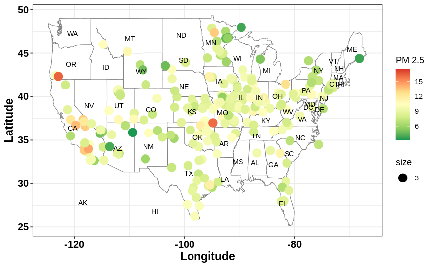

```r
## aggregate for point data
### for pm2.5
a <-
  pmaqi %>%dplyr::select(sitenum, long, lat, pm25, aqi) %>%
  group_by(sitenum) %>%
  summarise(pm25 = mean(pm25), aqi = mean(aqi), long = mean(long), lat = mean(lat)) %>%
  gather(key = class, value = value, -long, -lat, -sitenum) %>%
  filter(long > -125)
a1 <- a[a$class == "pm25", ]
ggplot() +
  geom_polygon(aes(x = long, y = lat, group = group),
               fill = "white", colour = "gray50", size = 0.3, data = states) +
  geom_point(aes(x = long, y = lat, color = value, size=3), data = a1) +
   #geom_text(data=States, aes(long, lat, label = state_abbv), size=2)+
  scale_color_distiller("PM 2.5", palette = "RdYlGn")+
  geom_path(size = 0.1)+theme_bw()+
  geom_text(data=centroids, aes(x=long,y=lat, group=NA, label=abb),
          size=3, vjust=0.8, hjust=0.8)+xlab("Longitude")+ylab("Latitude")+theme(
            # LAIDES APPEARANCE
            plot.title = element_text(size=14, face= "bold", colour= "black" ),
            axis.title.x = element_text(size=14, face="bold", colour = "black"),
            axis.title.y = element_text(size=14, face="bold", colour = "black"),
            axis.text.x = element_text(size=12, face="bold", colour = "black"),
            # axis.text.y = element_text(size=12,  colour = "black"), # unbold
            axis.text.y = element_text(size=12, face="bold", colour = "black"), # bold
          )
```

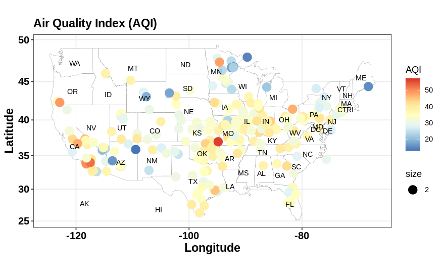

```r
### for aqi index
a2 <- a[a$class == "aqi", ]
ggplot() +
  geom_polygon(aes(x = long, y = lat, group = group),
               fill = "white", colour = "gray50", size = 0.1,
               data = states) +
  geom_point(aes(x = long, y = lat, color = value,size=2), data = a2) +
  scale_color_distiller("AQI", palette = "RdYlBu", direction = -1) +
  xlab("Longitude") + ylab("Latitude") +
  ggtitle("Air Quality Index (AQI)") +
  coord_map() +
  geom_path(size = 0.1)+theme_bw()+
  geom_text(data=centroids, aes(x=long,y=lat, group=NA, label=abb),
          size=3, vjust=0.8, hjust=0.8)+xlab("Longitude")+ylab("Latitude")+theme(
            # LAIDES APPEARANCE
            plot.title = element_text(size=14, face= "bold", colour= "black" ),
            axis.title.x = element_text(size=14, face="bold", colour = "black"),
            axis.title.y = element_text(size=14, face="bold", colour = "black"),
            axis.text.x = element_text(size=12, face="bold", colour = "black"),
            # axis.text.y = element_text(size=12,  colour = "black"), # unbold
            axis.text.y = element_text(size=12, face="bold", colour = "black"), # bold
          )
```

#County data setup with counties population more than 1M

```r
library(lubridate)
#round dates down to week
df<-pmaqi
df$year <- floor_date(df$date, "year")
df$State<-state.abb[match(df$statename, state.name)]
df<-df %>%
  group_by(sitenum,year,statename,countyname,long,lat, State) %>%
  summarize(pm25 = mean(pm25), aqi=mean(aqi))
```

[output not shown]

```r
df$abbr<-state.abb[match(df$statename, state.name)]
df<-df%>%dplyr::rename(county=countyname)
df<-merge(df,countypop,by=c("county","abbr"))
#combine county population
#data("countypop")
```

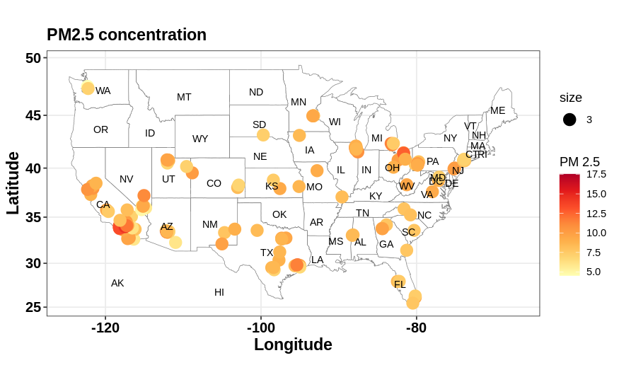

```r
## aggregate for point data
### for pm2.5
a <-
  df %>%filter(pop_2015>1000000) %>%dplyr::select(sitenum, long, lat, pm25,aqi) %>%
  group_by(sitenum) %>%
  summarise(pm25 = mean(pm25), aqi=mean(aqi),long = mean(long), lat = mean(lat)) %>%
  gather(key = class, value = value, -long, -lat, -sitenum) %>%
  filter(long > -125)
a4 <- a[a$class == "pm25", ]
ggplot() +
  geom_polygon(aes(x = long, y = lat, group = group),
               fill = "white", colour = "gray50", size = 0.2, data = states) +
  geom_point(aes(x = long, y = lat, color = value,size=3), data = a4) +
   #geom_text(data=States, aes(long, lat, label = state_abbv), size=2)+
  scale_color_distiller("PM 2.5", palette = "YlOrRd",direction = 1) +
  xlab("Longitude") + ylab("Latitude") +
  ggtitle("PM2.5 concentration") +
  coord_map() +
  geom_path(size = 0.1)+theme_bw()+
  geom_text(data=centroids, aes(x=long,y=lat, group=NA, label=abb),
          size=3, vjust=0.8, hjust=0.8)+xlab("Longitude")+ylab("Latitude")+theme(
            # LAIDES APPEARANCE
            plot.title = element_text(size=14, face= "bold", colour= "black" ),
            axis.title.x = element_text(size=14, face="bold", colour = "black"),
            axis.title.y = element_text(size=14, face="bold", colour = "black"),
            axis.text.x = element_text(size=12, face="bold", colour = "black"),
            # axis.text.y = element_text(size=12,  colour = "black"), # unbold
            axis.text.y = element_text(size=12, face="bold", colour = "black"), # bold
          )
```

The populated counties have PM$_{2.5}$ mostly in cutt of range but still there are many stations where numbers are greater than $12 \frac{ug}{m^3}$. However, if we want to look into the counties whose stations have mean PM$_{2.5}$ concentrations greater than $12 \frac{ug}{m^3}$.

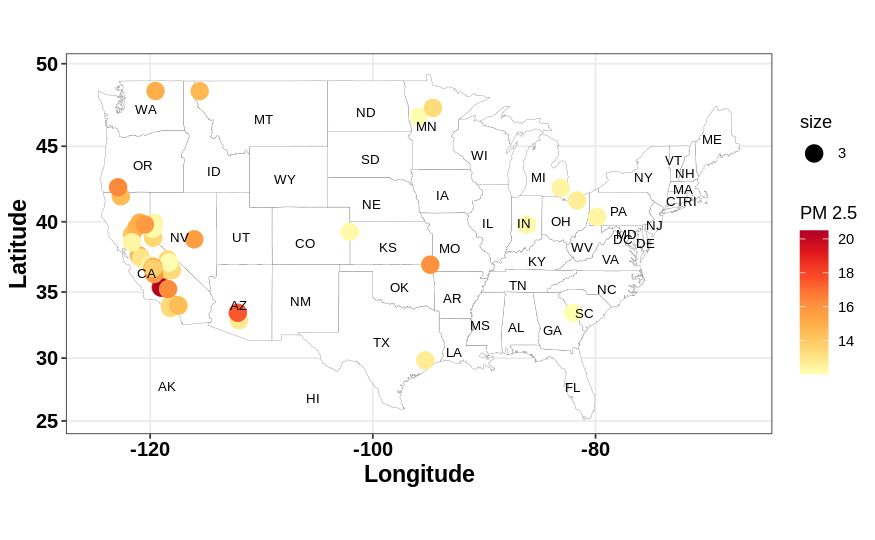

```r
## aggregate for point data
### for pm2.5
a <-
  df %>%filter(pm25>12) %>%dplyr::select(sitenum, long, lat, pm25,aqi) %>%
  group_by(sitenum) %>%
  summarise(pm25 = mean(pm25), aqi=mean(aqi),long = mean(long), lat = mean(lat)) %>%
  gather(key = class, value = value, -long, -lat, -sitenum) %>%
  filter(long > -125)
a4 <- a[a$class == "pm25", ]
ggplot() +
  geom_polygon(aes(x = long, y = lat, group = group),
               fill = "white", colour = "gray50", size = 0.1, data = states) +
  geom_point(aes(x = long, y = lat, color = value, size=3), data = a4) +
   #geom_text(data=States, aes(long, lat, label = state_abbv), size=2)+
  scale_color_distiller("PM 2.5", palette = "YlOrRd",direction = 1,)+
  geom_path(size = 0.1)+theme_bw()+coord_map()+
  geom_text(data=centroids, aes(x=long,y=lat, group=NA, label=abb),
          size=2.8, vjust=0.8, hjust=0.8)+xlab("Longitude")+ylab("Latitude")+theme(
            # LAIDES APPEARANCE
            plot.title = element_text(size=14, face= "bold", colour= "black" ),
            axis.title.x = element_text(size=14, face="bold", colour = "black"),
            axis.title.y = element_text(size=14, face="bold", colour = "black"),
            axis.text.x = element_text(size=12, face="bold", colour = "black"),
            # axis.text.y = element_text(size=12,  colour = "black"), # unbold
            axis.text.y = element_text(size=12, face="bold", colour = "black"), # bold
          )
```

Creating choropleth maps of good, and bad:unhealthy for sensitive group air quality days were there as defined by EPA [2].

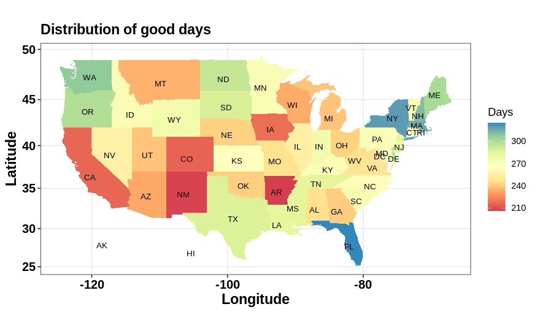

```r
## aggregate aqi by state (areal level)
states <- map_data("state")
aqi$State <- stringr::str_to_lower(aqi$State)
a <-
  aqi %>%
  dplyr::select(State, `Good Days`, `Unhealthy for Sensitive Groups Days`,`Hazardous Days`) %>%
  group_by(State) %>%
  summarise(good = mean(`Good Days`),
            unhealthy = mean(`Unhealthy for Sensitive Groups Days`),
            hazardous = mean(`Hazardous Days`))
a <-
  states %>%
  left_join(a,  by = c("region" = "State"))

ggplot() +
  geom_polygon(aes(x = long, y = lat, group = group, fill = good),
               data = a) +
  scale_fill_distiller("Days", palette = "Spectral",direction = 1) +
  xlab("Longitude") + ylab("Latitude") +
  ggtitle("Distribution of good days") +
  geom_path(size = 0.1)+theme_bw()+coord_map()+
  geom_text(data=centroids, aes(x=long,y=lat, group=NA, label=abb),
          size=2.8, vjust=0.8, hjust=0.8)+xlab("Longitude")+ylab("Latitude")+theme(
            # LAIDES APPEARANCE
            plot.title = element_text(size=14, face= "bold", colour= "black" ),
            axis.title.x = element_text(size=14, face="bold", colour = "black"),
            axis.title.y = element_text(size=14, face="bold", colour = "black"),
            axis.text.x = element_text(size=12, face="bold", colour = "black"),
            # axis.text.y = element_text(size=12,  colour = "black"), # unbold
            axis.text.y = element_text(size=12, face="bold", colour = "black"), # bold
          )
```

We can similarly plot the unhealthy days in each state and see how that varying from state to state

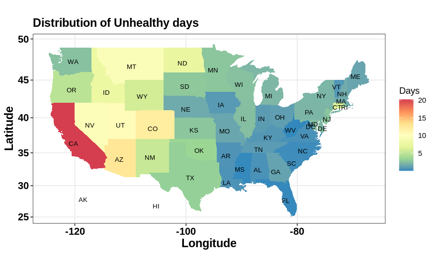

```r
ggplot() +
  geom_polygon(aes(x = long, y = lat, group = group, fill = unhealthy),
               data = a) +
  scale_fill_distiller("Days", palette = "Spectral",direction = -1) +
  xlab("Longitude") + ylab("Latitude") +
  ggtitle("Distribution of Unhealthy days") +
  geom_path(size = 0.1)+theme_bw()+coord_map()+
  geom_text(data=centroids, aes(x=long,y=lat, group=NA, label=abb),
          size=2.8, vjust=0.8, hjust=0.8)+xlab("Longitude")+ylab("Latitude")+theme(
            # LAIDES APPEARANCE
            plot.title = element_text(size=14, face= "bold", colour= "black" ),
            axis.title.x = element_text(size=14, face="bold", colour = "black"),
            axis.title.y = element_text(size=14, face="bold", colour = "black"),
            axis.text.x = element_text(size=12, face="bold", colour = "black"),
            # axis.text.y = element_text(size=12,  colour = "black"), # unbold
            axis.text.y = element_text(size=12, face="bold", colour = "black"), # bold
          )
```

Finally, we can plot the hazardous days on map

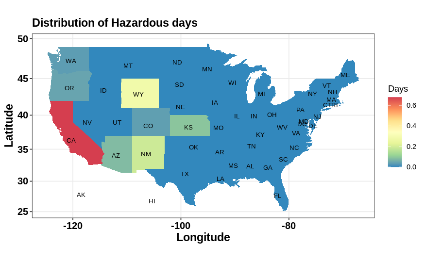

```r
ggplot() +
  geom_polygon(aes(x = long, y = lat, group = group, fill = hazardous),
               data = a) +
  scale_fill_distiller("Days", palette = "Spectral",direction = -1) +
  xlab("Longitude") + ylab("Latitude") +
  ggtitle("Distribution of Hazardous days") +
  geom_path(size = 0.1)+theme_bw()+coord_map()+
  geom_text(data=centroids, aes(x=long,y=lat, group=NA, label=abb),
          size=2.8, vjust=0.8, hjust=0.8)+xlab("Longitude")+ylab("Latitude")+theme(
            # LAIDES APPEARANCE
            plot.title = element_text(size=14, face= "bold", colour= "black" ),
            axis.title.x = element_text(size=14, face="bold", colour = "black"),
            axis.title.y = element_text(size=14, face="bold", colour = "black"),
            axis.text.x = element_text(size=12, face="bold", colour = "black"),
            # axis.text.y = element_text(size=12,  colour = "black"), # unbold
            axis.text.y = element_text(size=12, face="bold", colour = "black"), # bold
          )
```

The air quality in US is not bad, overall states have no hazardous days except few.

Conclusion: Maps are very helpful for visualization of spatial data where we want to see the spatial distribution of data. This project helped us to visualize air quality data on US map.

References: [1] https://www.epa.gov/pm-pollution/national-ambient-air-quality-standards-naaqs-pm [2] https://www.epa.gov/outdoor-air-quality-data/air-data-basic-information#:~:text=The%20AQI%20(Air%20Quality%20Index)&text=The%20AQI%20is%20an%20index,runs%20from%200%20to%20500.